# Assignmnet 7

Load neccessary packges:

```r
library(pacman)
p_load(tidyverse, magrittr, psych, caret, readxl, MASS, tree, randomForest, gbm)
```

Load the data sets: Italian wines: italianwines.csv Portuguese wines: winedata.xlsx

```r
italwines <- read.csv("../data/italianwines.csv")
portwines <- read_excel("../data/Wine_data.xlsx")
```

Italian wines: classify wine region and vintage on the basis of chemical properties of the wine Wine: geographic origin of the wine

Question 1a: Predict italian wine type according to its physical properties

Step 1: Describe the data

Step 1A: Descriptive tables First it is neccessary to see how many wine regions there are, as well as how many samples were taken from each region.

```r
table(italwines$wine)
```

```
   Barbera     Barolo Grignolino
        48         59         71
```

There are 3 type of wine: Barbera, Barolo, and Grignolino. There is an unequal sampling of each type.

Next, we look at the descriptive statistics for each variable, shown seperately for each wine type

```r
describewine <- describeBy(italwines, group = italwines$wine)
describewine
```

```
 Descriptive statistics by group
group: Barbera
```

|  | vars | n | mean | sd | median | trimmed | mad | min | max | range | skew | kurtosis | se |
| --- | --- | --- | --- | --- | --- | --- | --- | --- | --- | --- | --- | --- | --- |
| X* | 1 | 48 | 24.50 | 14.00 | 24.50 | 24.50 | 17.79 | 1.00 | 48.00 | 47.00 | 0.00 | -1.28 | 2.02 |
| wine* | 2 | 48 | 1.00 | 0.00 | 1.00 | 1.00 | 0.00 | 1.00 | 1.00 | 0.00 | NaN | NaN | 0.00 |
| alcohol | 3 | 48 | 13.15 | 0.53 | 13.16 | 13.15 | 0.53 | 12.20 | 14.34 | 2.14 | 0.14 | -0.76 | 0.08 |
| sugar | 4 | 48 | 25.02 | 2.26 | 24.73 | 24.85 | 1.85 | 21.40 | 34.60 | 13.20 | 1.55 | 4.70 | 0.33 |
| acidity | 5 | 48 | 103.43 | 15.64 | 103.10 | 103.39 | 18.16 | 74.90 | 137.80 | 62.90 | 0.00 | -0.94 | 2.26 |
| tartaric | 6 | 48 | 2.60 | 0.74 | 2.78 | 2.62 | 0.77 | 0.99 | 3.87 | 2.88 | -0.27 | -0.70 | 0.11 |
| malic | 7 | 48 | 3.33 | 1.09 | 3.26 | 3.33 | 1.01 | 1.24 | 5.65 | 4.41 | 0.10 | -0.53 | 0.16 |
| uronic | 8 | 48 | 1.17 | 0.29 | 1.17 | 1.16 | 0.28 | 0.74 | 1.80 | 1.06 | 0.39 | -0.73 | 0.04 |
| pH | 9 | 48 | 3.26 | 0.16 | 3.25 | 3.26 | 0.15 | 2.98 | 3.64 | 0.66 | 0.36 | -0.43 | 0.02 |
| ash | 10 | 48 | 2.44 | 0.18 | 2.38 | 2.43 | 0.18 | 2.10 | 2.86 | 0.76 | 0.34 | -0.92 | 0.03 |

[output cut: 19 more lines]

```
---------------------------------------------------------------
group: Barolo
```

|  | vars | n | mean | sd | median | trimmed | mad | min | max | range | skew | kurtosis | se |
| --- | --- | --- | --- | --- | --- | --- | --- | --- | --- | --- | --- | --- | --- |
| X* | 1 | 59 | 149.00 | 17.18 | 149.00 | 149.00 | 22.24 | 120.00 | 178.00 | 58.00 | 0.00 | -1.26 | 2.24 |
| wine* | 2 | 59 | 2.00 | 0.00 | 2.00 | 2.00 | 0.00 | 2.00 | 2.00 | 0.00 | NaN | NaN | 0.00 |
| alcohol | 3 | 59 | 13.74 | 0.46 | 13.75 | 13.74 | 0.52 | 12.85 | 14.83 | 1.98 | 0.07 | -0.68 | 0.06 |
| sugar | 4 | 59 | 26.76 | 1.69 | 26.60 | 26.69 | 1.48 | 22.70 | 30.70 | 8.00 | 0.38 | 0.01 | 0.22 |
| acidity | 5 | 59 | 76.72 | 11.26 | 73.50 | 75.13 | 7.41 | 62.00 | 114.80 | 52.80 | 1.47 | 1.78 | 1.47 |
| tartaric | 6 | 59 | 1.64 | 0.32 | 1.63 | 1.63 | 0.37 | 1.05 | 2.39 | 1.34 | 0.19 | -0.72 | 0.04 |
| malic | 7 | 59 | 2.01 | 0.69 | 1.77 | 1.87 | 0.19 | 1.35 | 4.04 | 2.69 | 2.03 | 2.84 | 0.09 |
| uronic | 8 | 59 | 0.81 | 0.15 | 0.79 | 0.80 | 0.18 | 0.60 | 1.21 | 0.61 | 0.60 | -0.58 | 0.02 |
| pH | 9 | 59 | 3.33 | 0.12 | 3.33 | 3.33 | 0.13 | 3.01 | 3.57 | 0.56 | -0.37 | -0.17 | 0.02 |
| ash | 10 | 59 | 2.46 | 0.23 | 2.44 | 2.45 | 0.24 | 2.04 | 3.22 | 1.18 | 0.52 | 0.58 | 0.03 |

[output cut: 19 more lines]

```
---------------------------------------------------------------
group: Grignolino
```

|  | vars | n | mean | sd | median | trimmed | mad | min | max | range | skew | kurtosis | se |
| --- | --- | --- | --- | --- | --- | --- | --- | --- | --- | --- | --- | --- | --- |
| X* | 1 | 71 | 84.00 | 20.64 | 84.00 | 84.00 | 26.69 | 49.00 | 119.00 | 70.00 | 0.00 | -1.25 | 2.45 |
| wine* | 2 | 71 | 3.00 | 0.00 | 3.00 | 3.00 | 0.00 | 3.00 | 3.00 | 0.00 | NaN | NaN | 0.00 |
| alcohol | 3 | 71 | 12.28 | 0.54 | 12.29 | 12.25 | 0.46 | 11.03 | 13.86 | 2.83 | 0.56 | 0.51 | 0.06 |
| sugar | 4 | 71 | 24.23 | 1.96 | 24.20 | 24.23 | 1.73 | 18.30 | 29.60 | 11.30 | -0.05 | 0.57 | 0.23 |
| acidity | 5 | 71 | 81.03 | 17.64 | 78.00 | 79.95 | 21.20 | 50.50 | 123.60 | 73.10 | 0.44 | -0.82 | 2.09 |
| tartaric | 6 | 71 | 1.89 | 0.43 | 1.85 | 1.85 | 0.37 | 1.11 | 3.62 | 2.51 | 1.13 | 2.59 | 0.05 |
| malic | 7 | 71 | 1.93 | 1.02 | 1.61 | 1.76 | 0.67 | 0.74 | 5.80 | 5.06 | 1.56 | 2.21 | 0.12 |
| uronic | 8 | 71 | 0.83 | 0.15 | 0.81 | 0.82 | 0.15 | 0.54 | 1.24 | 0.70 | 0.35 | -0.54 | 0.02 |
| pH | 9 | 71 | 3.31 | 0.14 | 3.30 | 3.30 | 0.15 | 2.95 | 3.65 | 0.70 | 0.10 | -0.37 | 0.02 |
| ash | 10 | 71 | 2.24 | 0.32 | 2.24 | 2.24 | 0.33 | 1.36 | 3.23 | 1.87 | 0.17 | 0.67 | 0.04 |

[output cut: 19 more lines]

The above are summary tables of the variables by wine type (Barbera, Barolo, and Grignolino respectively) Observations:

1.There are no missing values for any of the variables

2: There are some problems with skewness and kurtosis, outlined below

Barbera: Sugar - skew = 1.55; kurtosis = 4.70 *Proanthocyanins - skew = 1.48; kurtosis = 3.16*

Barolo: Malic - skew = 2.03*; kurtosis = 2.84* Chloride - 4.90*; 27.40*

Grignolino: Tartaric - skew = 1.13; kurtosis = 2.59 *Malic - skew = 1.56; kurtosis = 2.21* Magnesium - skew = 2.03*; kurtosis = 4.46* Chloride - skew = 3.35*; kurtosis = 17.48* Flavanoids - skew = 1.12; kurtosis = 3.15 *Glycerol - skew = 1.21; kurtosis = 4.70*

Step 1B: exploratory boxplots There are 27 potential predictors. A series of boxplots should indicate which variables are most diffrentiated across the wine types, and thus may be useful as differential predictors. Boxplots are also useful for checking distribution and outliers.

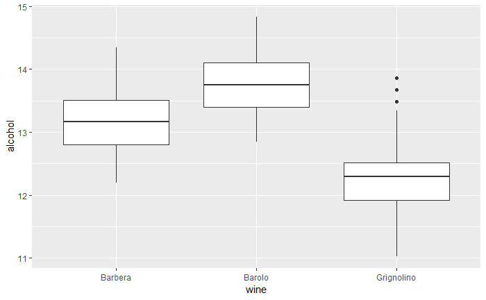

```r
italwines %>%
ggplot(mapping = aes(y = alcohol, x = wine))+
  geom_boxplot()
```

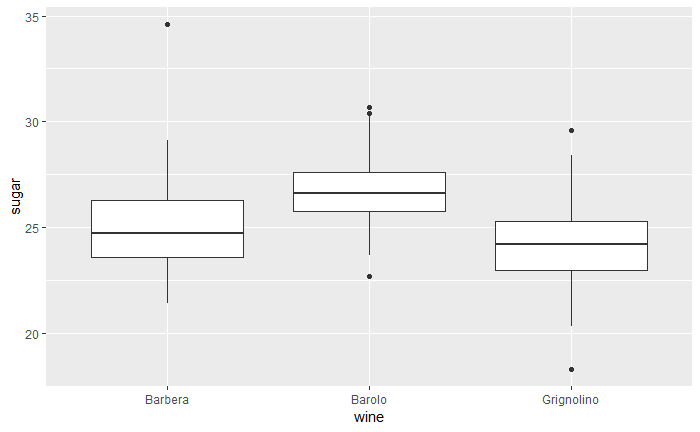

```r
italwines%>%
ggplot(mapping = aes(y = sugar, x = wine))+
  geom_boxplot()
```

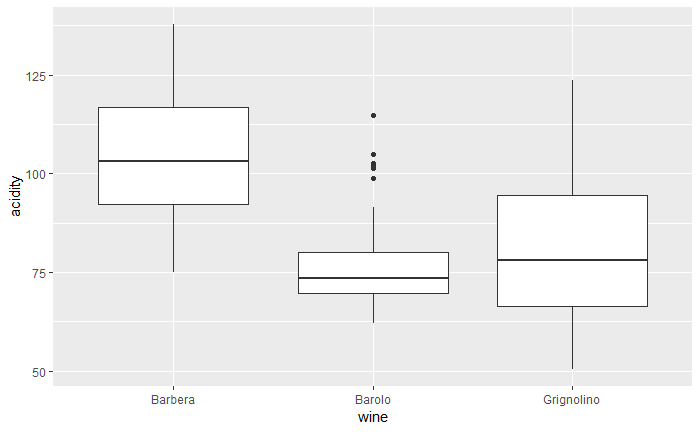

```r
italwines%>%
ggplot(mapping = aes(y = acidity, x = wine))+
  geom_boxplot()
```

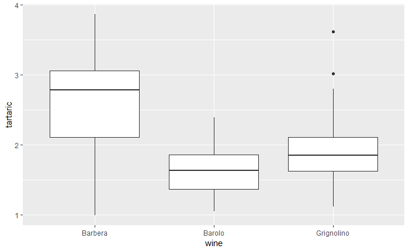

```r
italwines%>%
ggplot(mapping = aes(y = tartaric, x = wine))+
  geom_boxplot()
```

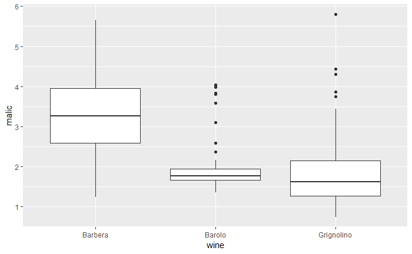

```r
italwines%>%
ggplot(mapping = aes(y = malic, x = wine))+
  geom_boxplot()
```

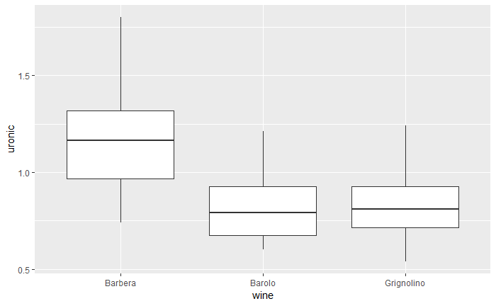

```r
italwines%>%
ggplot(mapping = aes(y = uronic, x = wine))+
  geom_boxplot()
```

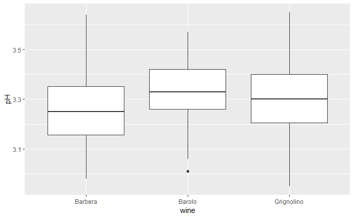

```r
italwines%>%
ggplot(mapping = aes(y = pH, x = wine))+
  geom_boxplot()
```

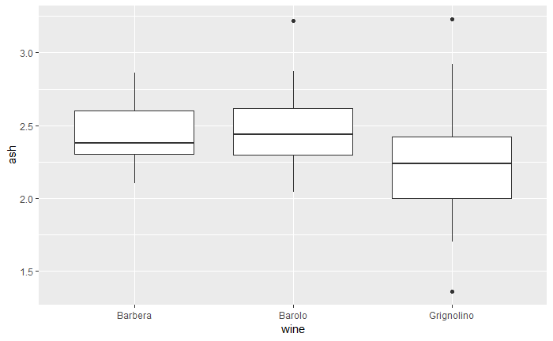

```r
italwines%>%
ggplot(mapping = aes(y = ash, x = wine))+
  geom_boxplot()
```

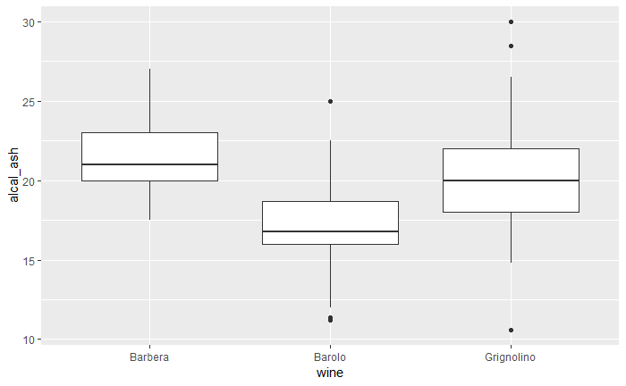

```r
italwines%>%
ggplot(mapping = aes(y = alcal_ash, x = wine))+
  geom_boxplot()
```

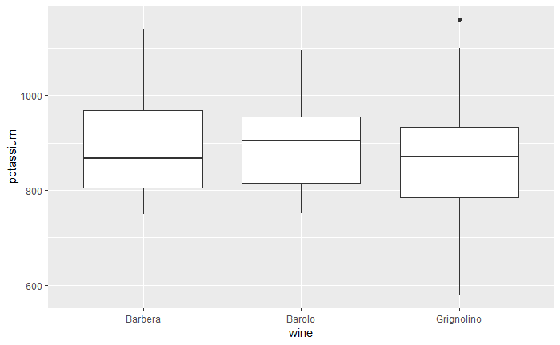

```r
italwines%>%
ggplot(mapping = aes(y = potassium, x = wine))+
  geom_boxplot()
```

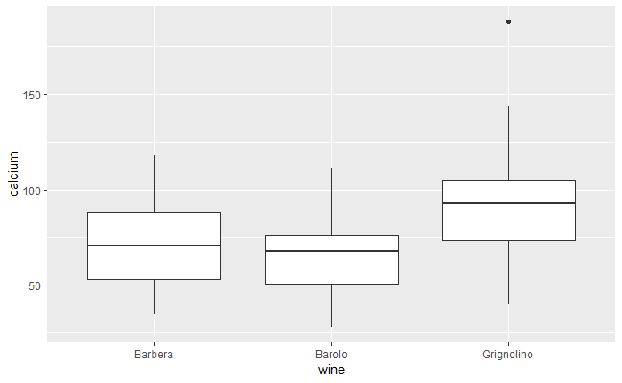

```r
italwines%>%
ggplot(mapping = aes(y = calcium, x = wine))+
  geom_boxplot()
```

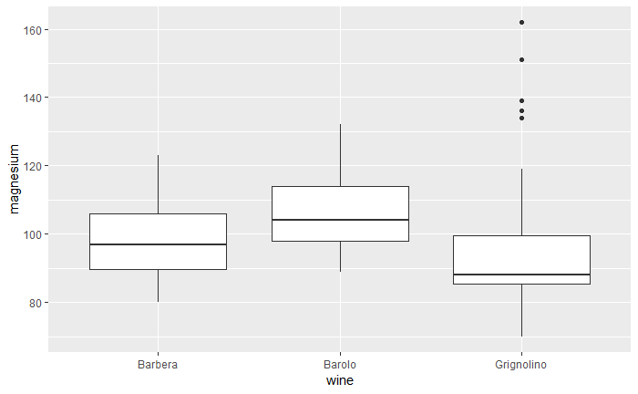

```r
italwines%>%
ggplot(mapping = aes(y = magnesium, x = wine))+
  geom_boxplot()
```

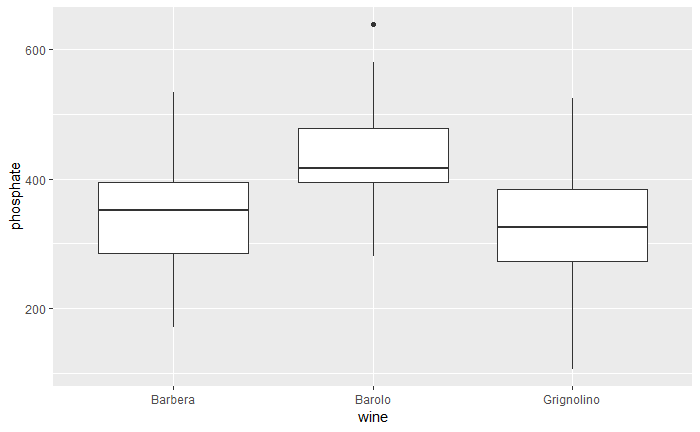

```r
italwines%>%
ggplot(mapping = aes(y = phosphate, x = wine))+
  geom_boxplot()
```

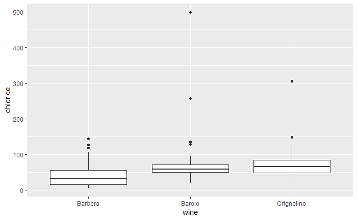

```r
italwines%>%
ggplot(mapping = aes(y = chloride, x = wine))+
  geom_boxplot()
```

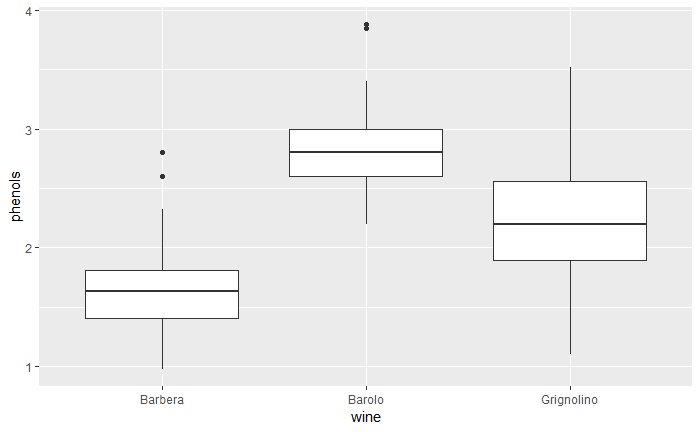

```r
italwines%>%
ggplot(mapping = aes(y = phenols, x = wine))+
  geom_boxplot()
```

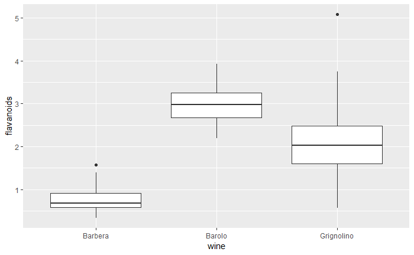

```r
italwines%>%
ggplot(mapping = aes(y = flavanoids, x = wine))+
  geom_boxplot()
```

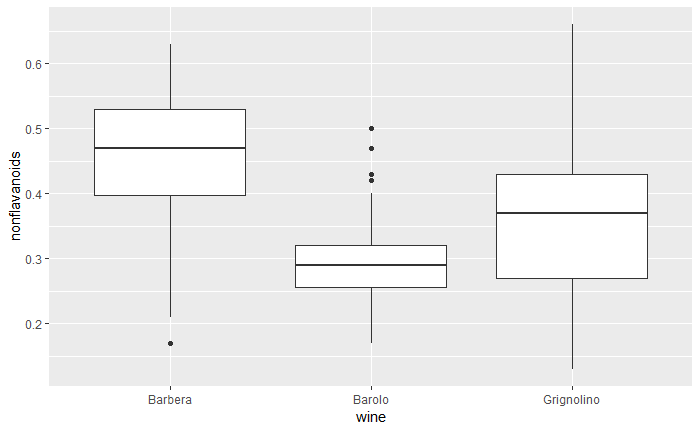

```r
italwines%>%
ggplot(mapping = aes(y = nonflavanoids, x = wine))+
  geom_boxplot()
```

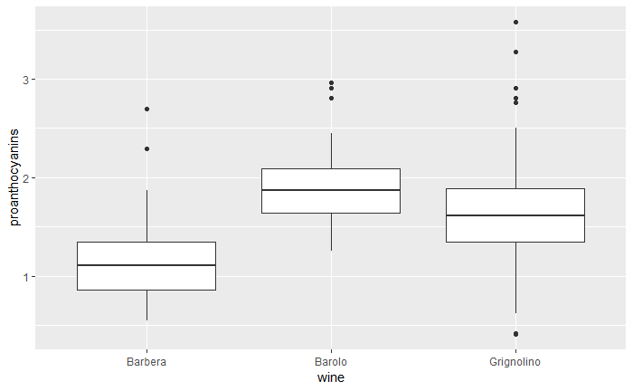

```r
italwines%>%
ggplot(mapping = aes(y = proanthocyanins, x = wine))+
  geom_boxplot()
```

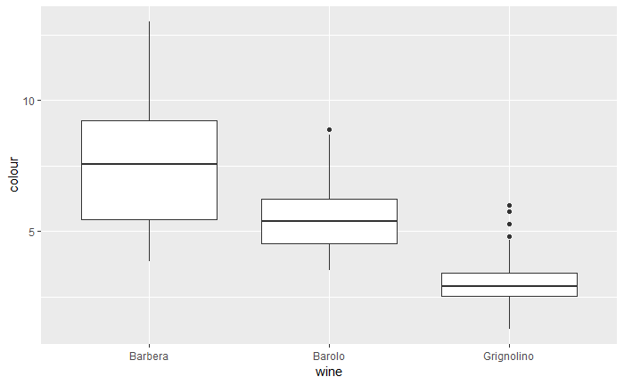

```r
italwines%>%
ggplot(mapping = aes(y = colour, x = wine))+
  geom_boxplot()
```

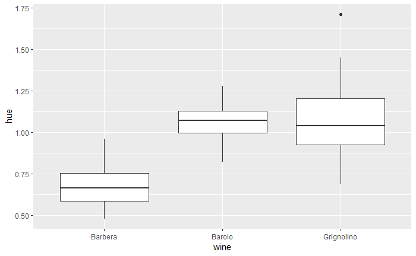

```r
italwines%>%
ggplot(mapping = aes(y = hue, x = wine))+
  geom_boxplot()
```

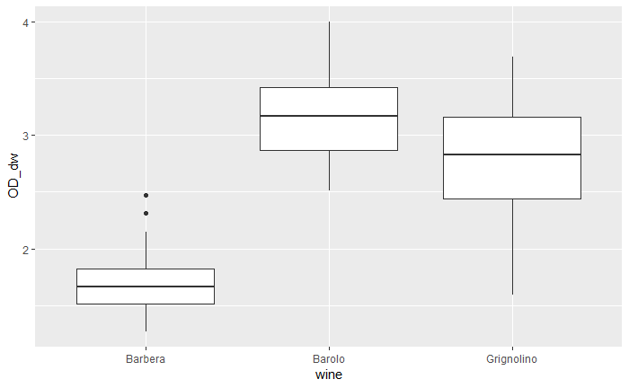

```r
italwines%>%
ggplot(mapping = aes(y = OD_dw, x = wine))+
  geom_boxplot()
```

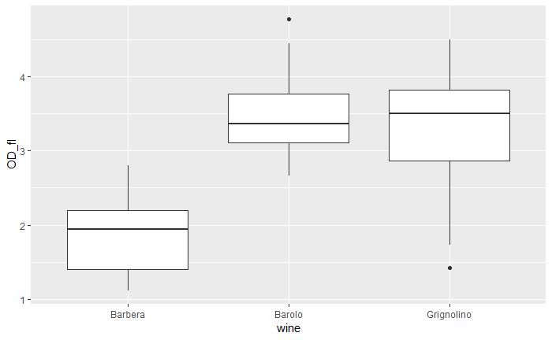

```r
italwines%>%
ggplot(mapping = aes(y = OD_fl, x = wine))+
  geom_boxplot()
```

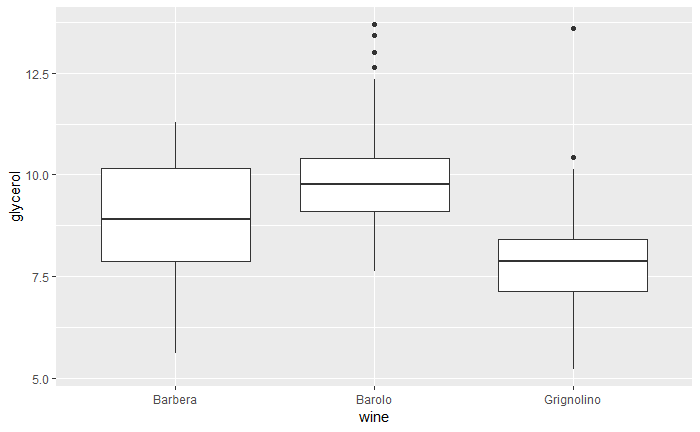

```r
italwines%>%
ggplot(mapping = aes(y = glycerol, x = wine))+
  geom_boxplot()
```

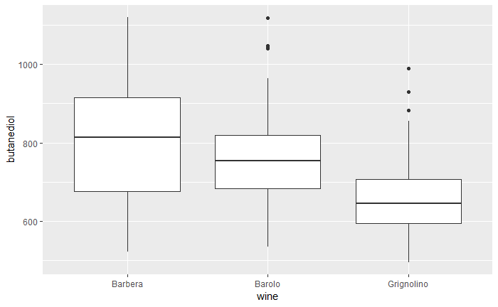

```r
italwines%>%
ggplot(mapping = aes(y = butanediol, x = wine))+
  geom_boxplot()
```

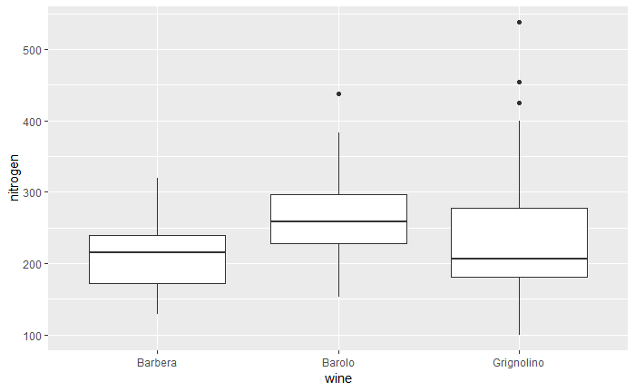

```r
italwines%>%
ggplot(mapping = aes(y = nitrogen, x = wine))+
  geom_boxplot()
```

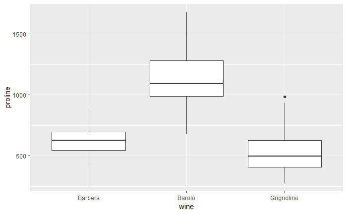

```r
italwines%>%
ggplot(mapping = aes(y = proline, x = wine))+
  geom_boxplot()
```

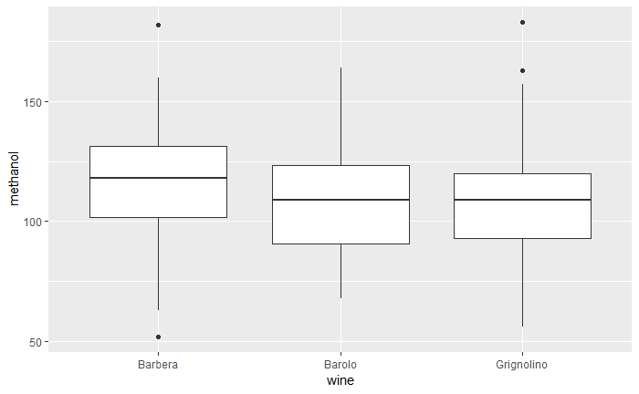

```r
italwines%>%
ggplot(mapping = aes(y = methanol, x = wine))+
  geom_boxplot()
```

Findings: Alcohol appears to be a good predictor. All 3 groups show acceptable distribution, with only a few outliers for the Grignolino type. The means are very diffrent, and there is little overlap of the IQRs across the groups.Phenols also appears to be a good predictor, with only a few outliers for the Barbera and Barolo groups.The same applies to flavanoids (although there is mild kurtosis with Grignolino), and color

Summary: Alcohol, phenols, flavanoids, and colour appear to be well differentiated acoss the groups, and seem to be good predictors

Step 2: Test a model with LDA (for later comparison to classification tree model)

Step 2A: LDA with all predictors (best possible LDA) LDA: for a linear discriminant anlysis I would first run a model with all the prdictors

```r
ital_lda1 <- lda(wine ~ alcohol + sugar + acidity + tartaric + malic + uronic + pH + ash + alcal_ash + potassium + calcium + magnesium + phosphate + chloride + phenols + flavanoids + nonflavanoids + proanthocyanins + colour + hue + OD_dw + OD_fl + glycerol + butanediol + nitrogen + proline + methanol, data = italwines)
ital_lda1
```

```
Call:
lda(wine ~ alcohol + sugar + acidity + tartaric + malic + uronic +
    pH + ash + alcal_ash + potassium + calcium + magnesium +
    phosphate + chloride + phenols + flavanoids + nonflavanoids +
    proanthocyanins + colour + hue + OD_dw + OD_fl + glycerol +
    butanediol + nitrogen + proline + methanol, data = italwines)

Prior probabilities of groups:
   Barbera     Barolo Grignolino
 0.2696629  0.3314607  0.3988764

Group means:
            alcohol    sugar   acidity tartaric    malic    uronic       pH      ash
Barbera    13.15375 25.01979 103.43125 2.599792 3.333750 1.1743750 3.264375 2.437083
Barolo     13.74475 26.76000  76.72203 1.641017 2.010678 0.8110169 3.330847 2.455593
Grignolino 12.27873 24.22521  81.03099 1.891690 1.932676 0.8253521 3.307042 2.244789
           alcal_ash potassium  calcium magnesium phosphate chloride  phenols
Barbera     21.41667  891.1042 71.93750   99.3125  345.0833 41.27083 1.678750
Barolo      17.03729  897.8475 64.88136  106.3390  428.5254 71.71186 2.840169
Grignolino  20.23803  860.0986 92.88732   94.5493  325.5070 71.69014 2.258873
           flavanoids nonflavanoids proanthocyanins   colour       hue    OD_dw
Barbera     0.7814583      0.447500        1.153542 7.396250 0.6827083 1.683542
Barolo      2.9823729      0.290000        1.899322 5.528305 1.0620339 3.157797
Grignolino  2.0808451      0.363662        1.630282 3.086620 1.0562817 2.785352
              OD_fl glycerol butanediol nitrogen   proline methanol
Barbera    1.886042 8.855833   806.4792 210.0625  629.8958 115.5417
Barolo     3.448475 9.982712   757.5254 272.4407 1115.7119 109.3220
Grignolino 3.331690 7.805634   660.7606 236.4225  519.5070 106.5352

Coefficients of linear discriminants:
                          LD1           LD2
alcohol          6.721717e-01 -0.6603192746
sugar           -8.845912e-02 -0.0075127763
acidity          1.808330e-02 -0.0161334797
tartaric        -3.190542e-01  0.0808791873
malic           -1.305066e-01 -0.2760408560
uronic          -1.552922e+00 -0.1637719555
pH               9.183025e-01 -1.2623944717
ash              5.910980e-01 -1.2308831422
alcal_ash       -1.646088e-01  0.1276068123
potassium        4.310689e-05 -0.0018916317
calcium          2.464321e-03  0.0096961444
magnesium        6.378506e-03 -0.0047638407
phosphate        2.152063e-03 -0.0024261551
chloride         1.984017e-04  0.0018069440
phenols         -5.088383e-01  0.2128103104
flavanoids       1.580357e+00  0.4162053548
nonflavanoids    1.200503e+00  1.7012054117
proanthocyanins -2.650821e-01  0.3809746063
colour          -3.500134e-01 -0.1752066715
hue              1.017463e+00  2.0171317463
OD_dw            1.062431e+00 -0.5011794373
OD_fl            1.191000e-02  0.5199491849
glycerol         1.907859e-01 -0.1727478797
butanediol      -2.594757e-03  0.0006356415
nitrogen        -2.116754e-03  0.0033392785
proline          3.307156e-03 -0.0031453078
methanol        -2.534324e-03 -0.0029154575

Proportion of trace:
   LD1    LD2
0.6956 0.3044
```

```r
ital_lda1predict <- predict(ital_lda1)
confusionMatrix(as.factor(ital_lda1predict$class), as.factor(italwines$wine),
                positive = c("1"))
```

```
Confusion Matrix and Statistics

            Reference
Prediction   Barbera Barolo Grignolino
  Barbera         48      0          0
  Barolo           0     59          0
  Grignolino       0      0         71

Overall Statistics

               Accuracy : 1
                 95% CI : (0.9795, 1)
    No Information Rate : 0.3989
    P-Value [Acc > NIR] : < 2.2e-16

                  Kappa : 1
 Mcnemar's Test P-Value : NA

Statistics by Class:

                     Class: Barbera Class: Barolo Class: Grignolino
Sensitivity                  1.0000        1.0000            1.0000
Specificity                  1.0000        1.0000            1.0000
Pos Pred Value               1.0000        1.0000            1.0000
Neg Pred Value               1.0000        1.0000            1.0000
Prevalence                   0.2697        0.3315            0.3989
Detection Rate               0.2697        0.3315            0.3989
Detection Prevalence         0.2697        0.3315            0.3989
Balanced Accuracy            1.0000        1.0000            1.0000
```

```r
italwinesforsigtest <- italwines %>%
                        dplyr::select(alcohol, sugar, acidity, tartaric, malic, uronic, pH, ash, alcal_ash, potassium, calcium, magnesium, phosphate, chloride, phenols, flavanoids, nonflavanoids, proanthocyanins, colour, hue, OD_dw, OD_fl, glycerol, butanediol, nitrogen, proline, methanol)
italwinesforsigtest <- as.matrix(italwinesforsigtest)
summary(manova(italwinesforsigtest ~ italwines$wine), test = "Wilks")
```

```
                Df    Wilks approx F num Df den Df    Pr(>F)
italwines$wine   2 0.012968   42.942     54    298 < 2.2e-16 ***
Residuals      175
---
Signif. codes:  0 ‘***’ 0.001 ‘**’ 0.01 ‘*’ 0.05 ‘.’ 0.1 ‘ ’ 1
```

From this attempt we can see that the variables are collinear. LD function 1 (LD1) is better than LD function 2 (LD2) The accuracy is perfect - 100% of wines samples are correctly classified by this model, which is 60% better than the no-information rate (40%). This model is highly significant. Specificity and sensitivity is perfect for all wine types.

Step 2B: LDA with selected variables Next we try a LDA with only the variables that seem to be good predictors from the descriptive stats and exploratory boxplots

```r
ital_lda2 <- lda(wine ~ alcohol + phenols + flavanoids + colour, data = italwines)
ital_lda2
```

```
Call:
lda(wine ~ alcohol + phenols + flavanoids + colour, data = italwines)

Prior probabilities of groups:
   Barbera     Barolo Grignolino
 0.2696629  0.3314607  0.3988764

Group means:
            alcohol  phenols flavanoids   colour
Barbera    13.15375 1.678750  0.7814583 7.396250
Barolo     13.74475 2.840169  2.9823729 5.528305
Grignolino 12.27873 2.258873  2.0808451 3.086620

Coefficients of linear discriminants:
                  LD1         LD2
alcohol    -0.3839192 -1.56940324
phenols     0.2019291  0.02074974
flavanoids -1.9944084 -0.27754655
colour      0.5143740 -0.22168059

Proportion of trace:
   LD1    LD2
0.7257 0.2743
```

```r
ital_lda2predict <- predict(ital_lda2)
confusionMatrix(as.factor(ital_lda2predict$class), as.factor(italwines$wine),
                positive = c("1"))
```

```
Confusion Matrix and Statistics

            Reference
Prediction   Barbera Barolo Grignolino
  Barbera         47      0          1
  Barolo           0     56          6
  Grignolino       1      3         64

Overall Statistics

               Accuracy : 0.9382
                 95% CI : (0.8921, 0.9688)
    No Information Rate : 0.3989
    P-Value [Acc > NIR] : < 2.2e-16

                  Kappa : 0.9063
 Mcnemar's Test P-Value : NA

Statistics by Class:

                     Class: Barbera Class: Barolo Class: Grignolino
Sensitivity                  0.9792        0.9492            0.9014
Specificity                  0.9923        0.9496            0.9626
Pos Pred Value               0.9792        0.9032            0.9412
Neg Pred Value               0.9923        0.9741            0.9364
Prevalence                   0.2697        0.3315            0.3989
Detection Rate               0.2640        0.3146            0.3596
Detection Prevalence         0.2697        0.3483            0.3820
Balanced Accuracy            0.9857        0.9494            0.9320
```

```r
italwinesforsigtest2 <- italwines %>%
                        dplyr::select(alcohol, phenols, flavanoids, colour)
italwinesforsigtest2 <- as.matrix(italwinesforsigtest2)
summary(manova(italwinesforsigtest2 ~ italwines$wine), test = "Wilks")
```

```
                Df    Wilks approx F num Df den Df    Pr(>F)
italwines$wine   2 0.061236   130.77      8    344 < 2.2e-16 ***
Residuals      175
---
Signif. codes:  0 ‘***’ 0.001 ‘**’ 0.01 ‘*’ 0.05 ‘.’ 0.1 ‘ ’ 1
```

From the above LDA we can see that the first linear discriminant function (LD1) is much better than the second (LD2) The confusion matrix indicates that classification has remained mostly accurate for Barbera, but it has become less accurate for Barolo, and much less accurate Grignolino. This makes sense - as we saw a fair degree of overlap between these two in the exploratory boxplots. The model overall has remarkably become only slightly less accurate (from 100% to 94%), after the removal of 23 predictors! Sensitivity and specificity is still high for all groups (all above 90%), and the model overall is highly significant.

Step 2c: Correct for overfitting - LDA of selected variables with cross validation We must still be aware of the problem of overfitting, so ideally we would use test/training groups or some form of cross-validation. LDA has cross-validation built into the function, so let’s go with that

```r
ital_lda3 <- lda(wine ~ alcohol + phenols + flavanoids + colour, data = italwines, CV = TRUE)
confusionMatrix(ital_lda3$class, italwines$wine)
```

```
Confusion Matrix and Statistics

            Reference
Prediction   Barbera Barolo Grignolino
  Barbera         47      0          1
  Barolo           0     56          8
  Grignolino       1      3         62

Overall Statistics

               Accuracy : 0.927
                 95% CI : (0.8783, 0.9605)
    No Information Rate : 0.3989
    P-Value [Acc > NIR] : < 2.2e-16

                  Kappa : 0.8894
 Mcnemar's Test P-Value : NA

Statistics by Class:

                     Class: Barbera Class: Barolo Class: Grignolino
Sensitivity                  0.9792        0.9492            0.8732
Specificity                  0.9923        0.9328            0.9626
Pos Pred Value               0.9792        0.8750            0.9394
Neg Pred Value               0.9923        0.9737            0.9196
Prevalence                   0.2697        0.3315            0.3989
Detection Rate               0.2640        0.3146            0.3483
Detection Prevalence         0.2697        0.3596            0.3708
Balanced Accuracy            0.9857        0.9410            0.9179
```

There is a minor drop in accuracy (94% to 93%), but the model is still excellent. This suggests that wine type (Barbera, Barolo, or Grignolino) can be predicted quite accurately by just 4 physical characteristics: alcohol, phenols, flavanoids, and color.

Step 3: Now to compare this simple approach to other approaches:

Step 3A: Classifcation tree

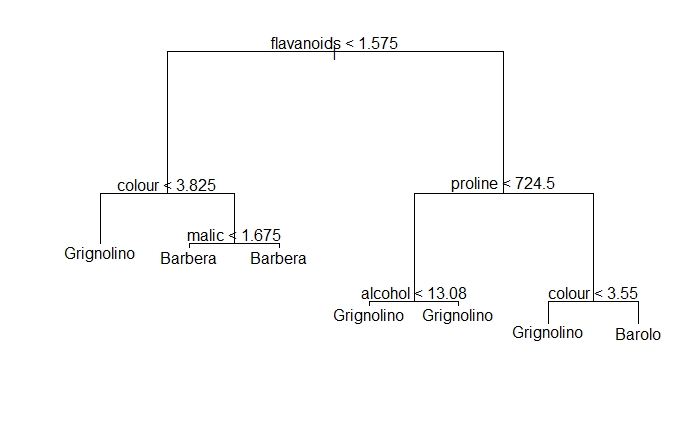

```r
italtree1 = tree(as.factor(wine) ~ alcohol + sugar + acidity + tartaric + malic + uronic + pH + ash + alcal_ash + potassium + calcium + magnesium + phosphate + chloride + phenols + flavanoids + nonflavanoids + proanthocyanins + colour + hue + OD_dw + OD_fl + glycerol + butanediol + nitrogen + proline + methanol, data = italwines)
plot(italtree1)
text(italtree1, pretty = 1)
```

```r
summary(italtree1)
```

```
Classification tree:
tree(formula = as.factor(wine) ~ alcohol + sugar + acidity +
    tartaric + malic + uronic + pH + ash + alcal_ash + potassium +
    calcium + magnesium + phosphate + chloride + phenols + flavanoids +
    nonflavanoids + proanthocyanins + colour + hue + OD_dw +
    OD_fl + glycerol + butanediol + nitrogen + proline + methanol,
    data = italwines)
Variables actually used in tree construction:
[1] "flavanoids" "colour"     "malic"      "proline"    "alcohol"
Number of terminal nodes:  7
Residual mean deviance:  0.08779 = 15.01 / 171
Misclassification error rate: 0.01685 = 3 / 178
```

```r
predict.italtree1 = predict(italtree1, type = "class")
confusionMatrix(as.factor(predict.italtree1), as.factor(italwines$wine))
```

```
Confusion Matrix and Statistics

            Reference
Prediction   Barbera Barolo Grignolino
  Barbera         48      0          1
  Barolo           0     57          0
  Grignolino       0      2         70

Overall Statistics

               Accuracy : 0.9831
                 95% CI : (0.9515, 0.9965)
    No Information Rate : 0.3989
    P-Value [Acc > NIR] : < 2.2e-16

                  Kappa : 0.9744
 Mcnemar's Test P-Value : NA

Statistics by Class:

                     Class: Barbera Class: Barolo Class: Grignolino
Sensitivity                  1.0000        0.9661            0.9859
Specificity                  0.9923        1.0000            0.9813
Pos Pred Value               0.9796        1.0000            0.9722
Neg Pred Value               1.0000        0.9835            0.9906
Prevalence                   0.2697        0.3315            0.3989
Detection Rate               0.2697        0.3202            0.3933
Detection Prevalence         0.2753        0.3202            0.4045
Balanced Accuracy            0.9962        0.9831            0.9836
```

The classification tree classifies wine type based on 5 physical characteristics: flavanoids, colour, malic, proline, and alcohol. [I noted that the variable “malic” has a bit of a problematic distributions for the groups: Barolo (skew = 2.03*; kurtosis = 2.84*), and Grignolino (skew = 1.56; kurtosis = 2.21*).There are also a fair amount of outliers for the “malic variable” in the groups: Barolo (8/59 observations are outliers), and Grignolino (5/71 observations are outliers). I would be hesitant to include this variable in the final model. And the variable “flavanoids” has a bit of a problematic distribution for Grignolino (skew = 1.12; kurtosis = 3.15), but on visual inspection of the boxplot it seems fine, and it only has 1 outlier]

The classification tree model (5 physical characteristics: flavanoids, colour, malic, proline, and alcohol) has a fair degree of overlap (3 variables) with the linear discriminant model we arrived at previously (4 physical characteristics: alcohol, phenols, flavanoids, and color). The misclassification error rate for the classification tree model is 3/178 (2%), while the misclassification error rate for the proposed lda model (without cross validation) was 11/178 (6%)

The better model is derived from the classification tree (98% accuracy and highly significant). We began with many variables of unknown importance, and it is possible to miss good predictor variables when manually choosing which ones to include in the lda (based off summary stats and exploratory graphs). If the lda is rerun with the predictor variables selected by the classification tree:

```r
ital_lda4 <- lda(wine ~ flavanoids + colour + malic + proline + alcohol, data = italwines)
ital_lda4
```

```
Call:
lda(wine ~ flavanoids + colour + malic + proline + alcohol, data = italwines)

Prior probabilities of groups:
   Barbera     Barolo Grignolino
 0.2696629  0.3314607  0.3988764

Group means:
           flavanoids   colour    malic   proline  alcohol
Barbera     0.7814583 7.396250 3.333750  629.8958 13.15375
Barolo      2.9823729 5.528305 2.010678 1115.7119 13.74475
Grignolino  2.0808451 3.086620 1.932676  519.5070 12.27873

Coefficients of linear discriminants:
                    LD1          LD2
flavanoids  1.663082846  0.356616503
colour     -0.517894986 -0.280067189
malic      -0.268883266 -0.379574518
proline     0.002772263 -0.003269574
alcohol     0.498286918 -0.923125274

Proportion of trace:
   LD1    LD2
0.6836 0.3164
```

```r
ital_lda4predict <- predict(ital_lda4)
confusionMatrix(as.factor(ital_lda4predict$class), as.factor(italwines$wine),
                positive = c("1"))
```

```
Confusion Matrix and Statistics

            Reference
Prediction   Barbera Barolo Grignolino
  Barbera         47      0          1
  Barolo           0     57          1
  Grignolino       1      2         69

Overall Statistics

               Accuracy : 0.9719
                 95% CI : (0.9357, 0.9908)
    No Information Rate : 0.3989
    P-Value [Acc > NIR] : < 2.2e-16

                  Kappa : 0.9573
 Mcnemar's Test P-Value : NA

Statistics by Class:

                     Class: Barbera Class: Barolo Class: Grignolino
Sensitivity                  0.9792        0.9661            0.9718
Specificity                  0.9923        0.9916            0.9720
Pos Pred Value               0.9792        0.9828            0.9583
Neg Pred Value               0.9923        0.9833            0.9811
Prevalence                   0.2697        0.3315            0.3989
Detection Rate               0.2640        0.3202            0.3876
Detection Prevalence         0.2697        0.3258            0.4045
Balanced Accuracy            0.9857        0.9788            0.9719
```

```r
italwinesforsigtest <- italwines %>%
  dplyr::select(colour + malic + proline + alcohol)
```

```
Error in .f(.x[[i]], ...) : object 'colour' not found
```

However, if we compare the misclassification error rate of the classification tree (3/178; with 5 variables) to the misclassification rate of the lda (5/178; with the same 5 variables) - we see that the classification tree makes less classification errors.

The above section of analysis indicates that: a) The classification tree approach leads to a slightly more accurate selection of predictor variables b) THe classification tree approach makes less classification errors than a lda model with the same variables (with accuracy rates of 98% and 97% respectively)

It is important to note that both of these methods are vulnerable to overfitting, and the classification tree may make less errors because of a greater degree of overfitting than the lda. We will have to compare these methods again once some form of cross validation has been introduced

Step 3B: Pruning First, we set a seed and split the data into test and training groups

```r
set.seed(1)
italtrain <- sample_frac(italwines, 0.75)
italtest <- setdiff(italwines, italtrain)
```

Then, we build a classification tree model on the training data

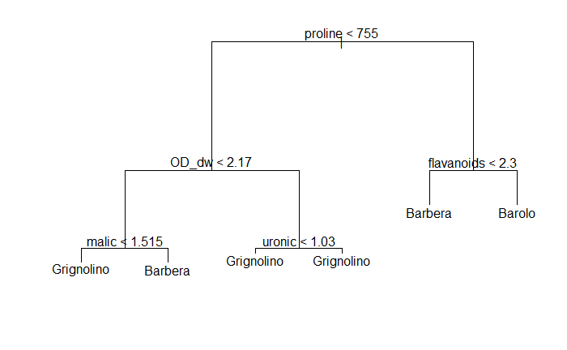

```r
italtrain.tree <- tree(as.factor(wine) ~ alcohol + sugar + acidity + tartaric + malic + uronic + pH + ash + alcal_ash + potassium + calcium + magnesium + phosphate + chloride + phenols + flavanoids + nonflavanoids + proanthocyanins + colour + hue + OD_dw + OD_fl + glycerol + butanediol + nitrogen + proline + methanol, data = italtrain)
plot(italtrain.tree)
text(italtrain.tree, pretty = 1)
```

```r
summary(italtrain.tree)
```

```
Classification tree:
tree(formula = as.factor(wine) ~ alcohol + sugar + acidity +
    tartaric + malic + uronic + pH + ash + alcal_ash + potassium +
    calcium + magnesium + phosphate + chloride + phenols + flavanoids +
    nonflavanoids + proanthocyanins + colour + hue + OD_dw +
    OD_fl + glycerol + butanediol + nitrogen + proline + methanol,
    data = italtrain)
Variables actually used in tree construction:
[1] "proline"    "OD_dw"      "malic"      "uronic"     "flavanoids"
Number of terminal nodes:  6
Residual mean deviance:  0.2135 = 27.32 / 128
Misclassification error rate: 0.05224 = 7 / 134
```

```r
predict.italtrain.tree = predict(italtrain.tree, type = "class")
confusionMatrix(as.factor(predict.italtrain.tree), as.factor(italtrain$wine))
```

```
Confusion Matrix and Statistics

            Reference
Prediction   Barbera Barolo Grignolino
  Barbera         33      1          3
  Barolo           0     44          0
  Grignolino       3      0         50

Overall Statistics

               Accuracy : 0.9478
                 95% CI : (0.8953, 0.9787)
    No Information Rate : 0.3955
    P-Value [Acc > NIR] : < 2.2e-16

                  Kappa : 0.9207
 Mcnemar's Test P-Value : NA

Statistics by Class:

                     Class: Barbera Class: Barolo Class: Grignolino
Sensitivity                  0.9167        0.9778            0.9434
Specificity                  0.9592        1.0000            0.9630
Pos Pred Value               0.8919        1.0000            0.9434
Neg Pred Value               0.9691        0.9889            0.9630
Prevalence                   0.2687        0.3358            0.3955
Detection Rate               0.2463        0.3284            0.3731
Detection Prevalence         0.2761        0.3284            0.3955
Balanced Accuracy            0.9379        0.9889            0.9532
```

The unpruned model built on the training data has a misclassification error rate of 7/134 (5%), thus an accuracy rate of 95%.

Determine alpha through cross validation

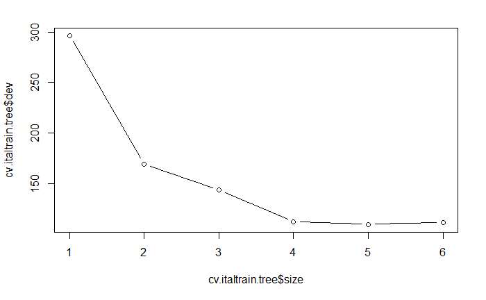

```r
cv.italtrain.tree <- cv.tree(italtrain.tree)
plot(cv.italtrain.tree$size, cv.italtrain.tree$dev, type = "b")
```

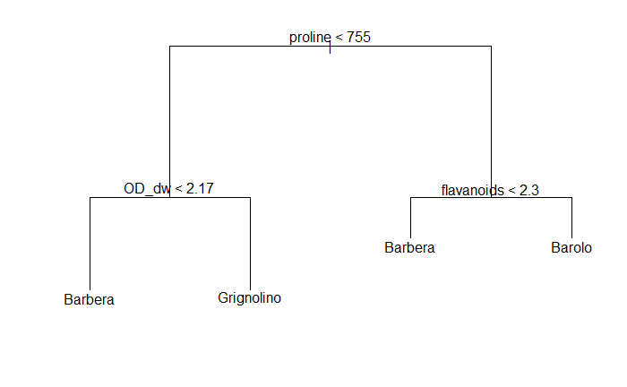

```r
prune.italtrain.tree =prune.tree(italtrain.tree, best = 4)
plot(prune.italtrain.tree)
text(prune.italtrain.tree, pretty = 1)
```

```r
summary(prune.italtrain.tree)
```

```
Classification tree:
snip.tree(tree = italtrain.tree, nodes = 5:4)
Variables actually used in tree construction:
[1] "proline"    "OD_dw"      "flavanoids"
Number of terminal nodes:  4
Residual mean deviance:  0.3508 = 45.6 / 130
Misclassification error rate: 0.0597 = 8 / 134
```

```r
predict.prune.italtrain.tree = predict(prune.italtrain.tree, type = "class")
confusionMatrix(as.factor(predict.prune.italtrain.tree), as.factor(italtrain$wine))
```

```
Confusion Matrix and Statistics

            Reference
Prediction   Barbera Barolo Grignolino
  Barbera         35      1          6
  Barolo           0     44          0
  Grignolino       1      0         47

Overall Statistics

               Accuracy : 0.9403
                 95% CI : (0.8858, 0.9739)
    No Information Rate : 0.3955
    P-Value [Acc > NIR] : < 2.2e-16

                  Kappa : 0.9101
 Mcnemar's Test P-Value : NA

Statistics by Class:

                     Class: Barbera Class: Barolo Class: Grignolino
Sensitivity                  0.9722        0.9778            0.8868
Specificity                  0.9286        1.0000            0.9877
Pos Pred Value               0.8333        1.0000            0.9792
Neg Pred Value               0.9891        0.9889            0.9302
Prevalence                   0.2687        0.3358            0.3955
Detection Rate               0.2612        0.3284            0.3507
Detection Prevalence         0.3134        0.3284            0.3582
Balanced Accuracy            0.9504        0.9889            0.9372
```

Step 3C: Comparison of pruned models Next we compare the accuracy of the pruned model across: pruned tree model on train data, pruned tree model on test data, pruned (3 variable) lda model on train data, and pruned (3 variable) lda model on test data

```r
predict.prune.italtest.tree = predict (prune.italtrain.tree, newdata = italtest, type = "class")
confusionMatrix(as.factor(predict.prune.italtest.tree), as.factor(italtest$wine))
```

```
Confusion Matrix and Statistics

            Reference
Prediction   Barbera Barolo Grignolino
  Barbera         12      0          5
  Barolo           0     12          1
  Grignolino       0      2         12

Overall Statistics

               Accuracy : 0.8182
                 95% CI : (0.6729, 0.9181)
    No Information Rate : 0.4091
    P-Value [Acc > NIR] : 3.272e-08

                  Kappa : 0.7288
 Mcnemar's Test P-Value : NA

Statistics by Class:

                     Class: Barbera Class: Barolo Class: Grignolino
Sensitivity                  1.0000        0.8571            0.6667
Specificity                  0.8438        0.9667            0.9231
Pos Pred Value               0.7059        0.9231            0.8571
Neg Pred Value               1.0000        0.9355            0.8000
Prevalence                   0.2727        0.3182            0.4091
Detection Rate               0.2727        0.2727            0.2727
Detection Prevalence         0.3864        0.2955            0.3182
Balanced Accuracy            0.9219        0.9119            0.7949
```

```r
ital_lda5 <- lda(wine ~ flavanoids + OD_dw + proline, data = italtrain)
ital_lda5
```

```
Call:
lda(wine ~ flavanoids + OD_dw + proline, data = italtrain)

Prior probabilities of groups:
   Barbera     Barolo Grignolino
 0.2686567  0.3358209  0.3955224

Group means:
           flavanoids    OD_dw   proline
Barbera     0.7719444 1.710833  622.3611
Barolo      2.9497778 3.205333 1112.4444
Grignolino  2.0733962 2.821321  517.9811

Coefficients of linear discriminants:
                   LD1          LD2
flavanoids 0.891173603  0.513990463
OD_dw      1.363453441  1.049709942
proline    0.004263496 -0.004282756

Proportion of trace:
   LD1    LD2
0.8575 0.1425
```

```r
ital_lda5predict <- predict(ital_lda5)
confusionMatrix(as.factor(ital_lda5predict$class), as.factor(italtrain$wine),
                positive = c("1"))
```

```
Confusion Matrix and Statistics

            Reference
Prediction   Barbera Barolo Grignolino
  Barbera         36      0          5
  Barolo           0     45          3
  Grignolino       0      0         45

Overall Statistics

               Accuracy : 0.9403
                 95% CI : (0.8858, 0.9739)
    No Information Rate : 0.3955
    P-Value [Acc > NIR] : < 2.2e-16

                  Kappa : 0.9102
 Mcnemar's Test P-Value : NA

Statistics by Class:

                     Class: Barbera Class: Barolo Class: Grignolino
Sensitivity                  1.0000        1.0000            0.8491
Specificity                  0.9490        0.9663            1.0000
Pos Pred Value               0.8780        0.9375            1.0000
Neg Pred Value               1.0000        1.0000            0.9101
Prevalence                   0.2687        0.3358            0.3955
Detection Rate               0.2687        0.3358            0.3358
Detection Prevalence         0.3060        0.3582            0.3358
Balanced Accuracy            0.9745        0.9831            0.9245
```

```r
test.ital_lda5predict <- predict(ital_lda5, newdata = italtest)
confusionMatrix(as.factor(test.ital_lda5predict$class), as.factor(italtest$wine),
                positive = c("1"))
```

```
Confusion Matrix and Statistics

            Reference
Prediction   Barbera Barolo Grignolino
  Barbera         12      0          4
  Barolo           0     12          1
  Grignolino       0      2         13

Overall Statistics

               Accuracy : 0.8409
                 95% CI : (0.6993, 0.9336)
    No Information Rate : 0.4091
    P-Value [Acc > NIR] : 4.778e-09

                  Kappa : 0.7616
 Mcnemar's Test P-Value : NA

Statistics by Class:

                     Class: Barbera Class: Barolo Class: Grignolino
Sensitivity                  1.0000        0.8571            0.7222
Specificity                  0.8750        0.9667            0.9231
Pos Pred Value               0.7500        0.9231            0.8667
Neg Pred Value               1.0000        0.9355            0.8276
Prevalence                   0.2727        0.3182            0.4091
Detection Rate               0.2727        0.2727            0.2955
Detection Prevalence         0.3636        0.2955            0.3409
Balanced Accuracy            0.9375        0.9119            0.8226
```

When applying the 3 variable (pruned) classification tree to the test data, the accuracy rate drops from 94% to 82%.

To compare with the equivalent lda model: The equivalent lda model (wine type modeled on 3 variables: flavanoids, OD_dw, and proline) had a misclassification error rate of 8/134 (6%) in the train data, compared to 7/44 (16%) in the test data. I.e.: Accuracy was 94% in training data, and 84% in test data

Conclusions: The pruned (3 variable) classification tree has an accuracy rate of 94% in the train set, which drops to 82% in the test set. This difference suggests there has been overfitting in the model. Furthermore, the lda model produces an identical accuracy rate to the classifcation tree in the train data (both 94%), but has a slightly better accuracy rate than the classification tree rate in the test data (84% and 82% respectively)

The results of the classification tree model can be replicated quite well with a lda model (i.e.: when cross validation is introduced, both classification trees and lda have similar accuracy rates, and the lda models confirm that a degree of overfitting occurred in the model).

Step 4: Bagging Bootstrap aggregation creates multiple trees from multiple bootstrapped samples, and then selects a tree that represents the aggregate of thhis data. This solves the problem of only having one random sample (the train set), which may in itself be biased.

Step 4A: Create a model (using bagging) for the traindata

```r
set.seed(5)
ital.bag <- randomForest(as.factor(wine) ~ alcohol + sugar + acidity + tartaric + malic + uronic + pH + ash + alcal_ash + potassium + calcium + magnesium + phosphate + chloride + phenols + flavanoids + nonflavanoids + proanthocyanins + colour + hue + OD_dw + OD_fl + glycerol + butanediol + nitrogen + proline + methanol,
mtry = 27, importance = TRUE, ntree = 5000,
data = italtrain)
```

Look at the accuracy rate in the test data:

```r
ital.bag.predict = predict(ital.bag, newdata = italtest)
confusionMatrix(as.factor(ital.bag.predict), as.factor(italtest$wine))
```

```
Confusion Matrix and Statistics

            Reference
Prediction   Barbera Barolo Grignolino
  Barbera         12      0          1
  Barolo           0     12          1
  Grignolino       0      2         16

Overall Statistics

               Accuracy : 0.9091
                 95% CI : (0.7833, 0.9747)
    No Information Rate : 0.4091
    P-Value [Acc > NIR] : 5.265e-12

                  Kappa : 0.8619
 Mcnemar's Test P-Value : NA

Statistics by Class:

                     Class: Barbera Class: Barolo Class: Grignolino
Sensitivity                  1.0000        0.8571            0.8889
Specificity                  0.9688        0.9667            0.9231
Pos Pred Value               0.9231        0.9231            0.8889
Neg Pred Value               1.0000        0.9355            0.9231
Prevalence                   0.2727        0.3182            0.4091
Detection Rate               0.2727        0.2727            0.3636
Detection Prevalence         0.2955        0.2955            0.4091
Balanced Accuracy            0.9844        0.9119            0.9060
```

The accuracy rate of the model in the test data improved to 91% with bagging, which is a big improvement from the accuracy rate of the pruned model in the test data (82%).

Next we need to see which variables were important in this model

```r
importance(ital.bag)
```

```
                    Barbera      Barolo Grignolino MeanDecreaseAccuracy
alcohol          9.14603551  37.6331957 25.5211829           36.6802719
sugar           -0.06169003   5.7156136  3.0558699            5.6169346
acidity         10.83974203   2.9949635  0.1482919           11.4026754
tartaric         7.65589467   5.1027849  1.8950193            8.2172052
malic            9.93424219   8.4251359  9.5654849           14.0153842
uronic          11.45897600   0.1557422 16.4581810           18.3202649
pH              -2.35515877  -0.4604100  0.5926174           -1.3888535
ash             10.29818168   2.3747141  3.4762451           10.3976262
alcal_ash       16.25825977   4.7916707  6.3008578           16.7608907
potassium       10.52621006   4.4169607 15.6332736           16.4896675
calcium         -0.34212384   4.7072382 11.1395600           10.7782102
magnesium       -1.50126073  11.6326763 10.2151848           11.9577247
phosphate       -1.12253416   4.8018525  3.5905318            4.9612739
chloride         2.23067877  -1.8923294 13.5185111           12.4289782
phenols          8.28560168  11.2752753 -3.7517048           11.6026964
flavanoids      58.42464432  63.8298461 30.7316696           76.2644492
nonflavanoids    2.09884220   3.3427577  2.3102164            4.2286952
proanthocyanins -0.52663440   5.2546236  6.1553791            6.5682100
colour          50.35177173  34.5271778 43.1555731           54.6256337
hue             37.07122043  12.6499976 19.2766049           37.9204474
OD_dw           56.24448671  33.0284127 39.0455154           57.9488419
OD_fl           21.49061184  20.1311505  6.2914716           23.1369110
glycerol         3.28884447  15.6292744 15.8063133           19.9952190
butanediol      -0.68108106  -1.3181524  4.6532105            2.7566599
nitrogen        11.39018361   4.9391219  5.3088161           12.3439549
proline         31.80573856 143.2371087 79.7806900          145.9796234
methanol        -1.62529498   1.2221770  1.4920693            0.5304973
                MeanDecreaseGini
alcohol               5.59340561
sugar                 0.11338840
acidity               0.19585792
tartaric              0.12972827
malic                 0.32413545
uronic                0.52492459
pH                    0.03045714
ash                   0.21190353
alcal_ash             0.40798044
potassium             0.57595796
calcium               0.19472950
magnesium             0.26780758
phosphate             0.07419530
chloride              0.21173737
phenols               0.33679441
flavanoids           15.48806316
nonflavanoids         0.07975145
proanthocyanins       0.24326599
colour               13.03996253
hue                   3.13162988
OD_dw                14.30434718
OD_fl                 2.71529986
glycerol              0.58907361
butanediol            0.07927316
nitrogen              0.31253892
proline              28.31042639
methanol              0.08370770
```

Here you can see the relative importance of factors, in terms of how useful they are for classification (discrimination between types of wine). We can see that alcohol, flavanoids, colour, OD_dw, and proline are mostly important, with hue and OD_fl playing a lesser role, and everything else contributing virtually nothing to the predictive value of the model. THe factors identified as important here overlap with both our initial proposed LDA model, and our first classification tree (before pruning).

To illustrate this visually:

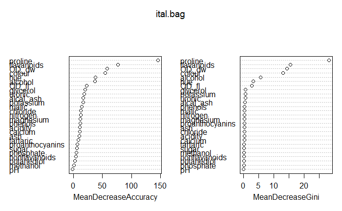

```r
varImpPlot(ital.bag)
```

Both the mean decrease in accuracy and the mean decrease in Gini confirm that the most valuable variables are: proline, flavanoids, OD_dw, colour, hue, alcohol and OD_fl (in roughly that order)

Step 5: Random Forests Overcomes the correlations of the samples and trees (as obtained by bootstrapping)

Step 5A: Use random forests to create a model on the train data, then see how accurate that model is in the test data

```r
italrf.bag <- randomForest(as.factor(wine) ~ alcohol + sugar + acidity + tartaric + malic + uronic + pH + ash + alcal_ash + potassium + calcium + magnesium + phosphate + chloride + phenols + flavanoids + nonflavanoids + proanthocyanins + colour + hue + OD_dw + OD_fl + glycerol + butanediol + nitrogen + proline + methanol,
mtry = sqrt(27), importance = TRUE,
data = italtrain)
predict.italrf.bag <- predict(italrf.bag, newdata = italtest)
confusionMatrix(as.factor(predict.italrf.bag), as.factor(italtest$wine))
```

```
Confusion Matrix and Statistics

            Reference
Prediction   Barbera Barolo Grignolino
  Barbera         12      0          1
  Barolo           0     14          1
  Grignolino       0      0         16

Overall Statistics

               Accuracy : 0.9545
                 95% CI : (0.8453, 0.9944)
    No Information Rate : 0.4091
    P-Value [Acc > NIR] : 1.696e-14

                  Kappa : 0.9314
 Mcnemar's Test P-Value : NA

Statistics by Class:

                     Class: Barbera Class: Barolo Class: Grignolino
Sensitivity                  1.0000        1.0000            0.8889
Specificity                  0.9688        0.9667            1.0000
Pos Pred Value               0.9231        0.9333            1.0000
Neg Pred Value               1.0000        1.0000            0.9286
Prevalence                   0.2727        0.3182            0.4091
Detection Rate               0.2727        0.3182            0.3636
Detection Prevalence         0.2955        0.3409            0.3636
Balanced Accuracy            0.9844        0.9833            0.9444
```

With random forests, the model is 95% accurate, which is a further improvement on the 91% accuracy we obtained with the bagging model.

Step 6: Boosting USing information from previous trees (from within the model) to create new ones

Step 6A: Create a boosted model

```r
italtrain.boost = gbm(wine ~ alcohol + sugar + acidity + tartaric + malic + uronic + pH + ash + alcal_ash + potassium + calcium + magnesium + phosphate + chloride + phenols + flavanoids + nonflavanoids + proanthocyanins + colour + hue + OD_dw + OD_fl + glycerol + butanediol + nitrogen + proline + methanol, data = italtrain, n.trees = 5000 , interaction.depth = 2)
```

```
Distribution not specified, assuming multinomial ...
```

|  | var | rel.inf |
| --- | --- | --- |
| proline | proline | 29.44264858 |
| colour | colour | 19.71405461 |
| flavanoids | flavanoids | 14.15151537 |
| alcohol | alcohol | 10.79669580 |
| OD_dw | OD_dw | 10.37400258 |
| hue | hue | 7.37633875 |
| glycerol | glycerol | 1.70109787 |
| OD_fl | OD_fl | 1.53036006 |
| malic | malic | 0.87160029 |
| potassium | potassium | 0.52528123 |

[output cut: 17 more lines]

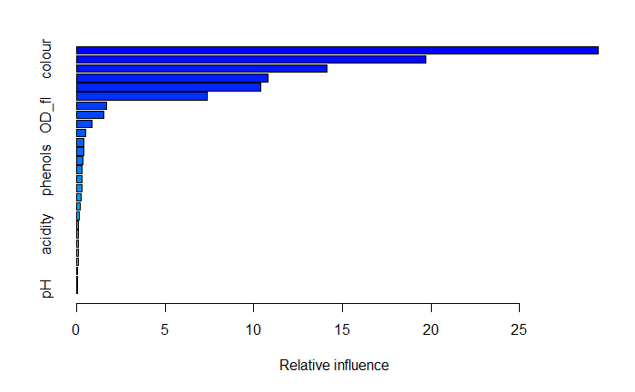

```r
summary(italtrain.boost)
```